# Module Five Activity

For the module five activity, you will write Python code to create clear and informative data visualizations from the provided data set `Most-Recent-Cohorts-Field-of-Study.csv`. Your code should be well-organized and reflect a clear understanding of each step in the visualization process.

*Note:* there are two parts to this assignment. Part One is the data visualization coding activity. Part Two is the reflection paper.

Once your code is complete, you will download this notebook as an HTML file by clicking **File**, then **Download As**, then **HTML (.html)** from the Jupyter menu bar. Validate that your code, output, and all six visualizations (rendered as images using the display() function) are visible in the html file before submission.

*Missing Blocks:* Ensure that you have clicked **Run** for all blocks before downloading as an HTML file or the block may be missing from your submission. **Images** must be called using the *display()* function, for example: **display(Image(filename="output/{image_name}.png"))**

Specifically, you must address the items from the rubric criteria.

### Part One: Data Visualization

#### Prepare the given data set for visualization. Consider the following:

- Are there any columns you can remove?
- Are filters or groupings needed?
- Are the data values structured for your chart types?

#### Clean the given data set for visualization using Python. Consider the following:

- Are there any missing or invalid values?
- Are there any unclear column names?
- Are the data types correct for each column (e.g., numeric, categorical, datetime)?

#### Create multiple types of visualizations using Python. Include the following:

- Dendrogram
- PCA scatterplot
- Cluster size distribution
- Feature importance heatmap
- Trend chart
- Scatterplot

*Note:* You will need to ensure that you have created at least one of each of the visual types listed above.

### Part 2: Reflection

*This part is to be completed in a word document, using the output here to answer the topics.*

#### Identify patterns in the data. Consider the following:

- Are there any clear trends, clusters, or outliers visible in your visualizations?
- Are certain variables showing consistent behavior or relationships?
- Are the patterns similar across different visualization types?

#### Draw conclusions from the patterns. Consider the following:

- Are your conclusions clearly based on the patterns you observed?
- Are your findings supported by multiple visuals or data points?

#### Explain how the visualizations validate your findings. Consider the following:

- Are specific chart elements (e.g., color, scale, labels) helping to highlight your findings?
- Are the insights you found something you could not easily see without the visuals?

#### Write a summary of the visualization choices you made. Include the following:

- An explanation of the types of charts you used
- An explanation of the formatting decisions to support visual clarity

*To Begin:* This Python template program has been broken down into segments as a guide for what steps you should do at a minimum to complete this activity. Look for the **# To Do:** comments. These are placeholders for you to provide Python code segments. Fill out all **# To Do:** code segments to complete this program.  
*Once Complete:* Execute a "Kernel restart and run all" to verify that all your code works as a single unit by clicking **Kernel**, then **Restart & Run All** before downloading as html.

*Hint:* If you need to install additional packages, see one of the earlier modules on how to configure and call a requirements.txt file.

## Import the Required Packages

- **pandas (pd):** For reading and manipulating the dataset.
- **MinMaxScaler:** A preprocessing tool from sklearn to normalize data values between 0 and 1.
- **PCA:** Principal Component Analysis (dimensionality reduction) from sklearn for visualizing clusters in 2D.
- **dendrogram, linkage, fcluster:** Tools from scipy for performing hierarchical clustering and visualizing its results.
- **matplotlib.pyplot (plt):** For creating charts and saving visuals.
- **seaborn (sns):** For advanced and visually appealing charts.
- **numpy (np):** For numerical operations like arrays and aggregations.

```python
import pandas as pd   # for reading & manipulating the dataset
from sklearn.preprocessing import MinMaxScaler    # a preprocessing tool from sklearn to normalize data values
                                                                                    # between 0 and 1
from sklearn.decomposition import PCA  # Principal Component Analysis (dimensionality reduction) from
                                                                   # sklearn for visualizing clusters in 2D
from scipy.cluster.hierarchy import dendrogram, linkage, fcluster    # tools from scipy for performing hierarchical clustering & visualizing its results
import matplotlib.pyplot as plt     #  for creating charts & saving visuals
import seaborn as sns    #  for advanced & visually appealing charts
import numpy as np      # for numerical operations like arrays & aggregations

from IPython.display import Image, display # for image rendering in html output
```

# Part One: Data Visualization

## Loading the Data

*Hints:* Use **pd.read_csv** to read a CSV file and load it into a DataFrame (data). Use **try block** to ensures the program handles errors gracefully if the file cannot be loaded (e.g., missing or incorrect path). Use **exit()** to stop the program if an error occurs.

```python
print("Loading dataset...")

try:
    df = pd.read_csv("data/Most-Recent-Cohorts-Field-of-Study.csv")
    print("Dataset loaded successfully.")
except Exception as e:
    print("Error loading dataset:", e)
```

```
Loading dataset...
Dataset loaded successfully.
```

## Display Dataset Information

*Hints:* Use **data.columns.tolist()** to extract and print all column names. Use **data.index.tolist()** to show the index values of the dataset (e.g., row numbers). Use **data.head()** to display the top 5 rows to give an overview of the data.

```python
print("Column Names:")
print(df.columns)
```

```
Column Names:
Index(['UNITID', 'OPEID6', 'INSTNM', 'CONTROL', 'MAIN', 'CIPCODE', 'CIPDESC',
       'CREDLEV', 'CREDDESC', 'IPEDSCOUNT1',
       ...
       'EARN_COUNT_PELL_WNE_5YR', 'EARN_PELL_WNE_MDN_5YR',
       'EARN_COUNT_NOPELL_WNE_5YR', 'EARN_NOPELL_WNE_MDN_5YR',
       'EARN_COUNT_MALE_WNE_5YR', 'EARN_MALE_WNE_MDN_5YR',
       'EARN_COUNT_NOMALE_WNE_5YR', 'EARN_NOMALE_WNE_MDN_5YR',
       'EARN_COUNT_HIGH_CRED_5YR', 'EARN_IN_STATE_5YR'],
      dtype='object', length=174)
```

```python
print("Row Index Labels:")
# all row data Labels
print(df.index)
```

```
Row Index Labels:
RangeIndex(start=0, stop=229188, step=1)
```

```python
print("First 5 Rows of the Dataset:")
print(df.head())
```

```
First 5 Rows of the Dataset:
     UNITID  OPEID6                    INSTNM CONTROL  MAIN  CIPCODE
0  100654.0    1002  Alabama A & M University  Public     1      100  \
1  100654.0    1002  Alabama A & M University  Public     1      101
2  100654.0    1002  Alabama A & M University  Public     1      109
3  100654.0    1002  Alabama A & M University  Public     1      110
4  100654.0    1002  Alabama A & M University  Public     1      110

                                 CIPDESC  CREDLEV           CREDDESC
0                  Agriculture, General.        3  Bachelor's Degree  \
1  Agricultural Business and Management.        3  Bachelor's Degree
2                       Animal Sciences.        3  Bachelor's Degree
3           Food Science and Technology.        3  Bachelor's Degree
4           Food Science and Technology.        5    Master's Degree

```

[output cut: 29 more lines]

## Inspect and Select Numeric Columns

*Hints:* Use **select_dtypes()** to filter columns with numeric data types (float64 and int64). Removes columns like **UNITID** and **OPEID6**, which are not useful for clustering. Use **dropna()** to remove rows with missing values to clean data for clustering, see also module three sample for additional cleaning examples. Use error handling **try blocks** to ensures the program stops if the column selection fails.

```python
print("Inspecting dataset to select numeric columns for clustering...")

try:
    # Select only numeric columns
    numeric_df = df.select_dtypes(
        include=['float64', 'int64']
    )

    # Remove ID columns not useful for clustering
    numeric_df = numeric_df.drop(
        columns=['UNITID', 'OPEID6'],
        errors='ignore'
    )

    # Remove rows with missing values
    numeric_df = numeric_df.dropna()

    print("Numeric columns selected successfully.")
    print(numeric_df.head())

except Exception as e:
    print("Error selecting numeric columns:", e)
```

```
Inspecting dataset to select numeric columns for clustering...
Numeric columns selected successfully.
   MAIN  CIPCODE  CREDLEV  IPEDSCOUNT1  IPEDSCOUNT2  DISTANCE
2     1      109        3          3.0          9.0         1
3     1      110        3          7.0         10.0         1
4     1      110        5          4.0          6.0         1
5     1      110        6          2.0          4.0         1
7     1      199        3          6.0          6.0         1
```

## Normalize the Data

*Hints:* Use **MinMaxScaler()** to scale data values between 0 and 1, ensuring all features are on the same scale. Use **fit_transform()** to fit the scaler to the data and transform it.

```python
print("Normalizing the data using MinMaxScaler...")

try:
    # Create scaler
    scaler = MinMaxScaler()

    # Fit scaler and transform numeric data
    scaled_data = scaler.fit_transform(numeric_df)

    # Convert back to DataFrame with original column names
    scaled_df = pd.DataFrame(
        scaled_data,
        columns=numeric_df.columns
    )

    print("Data normalized successfully.")
    print(scaled_df.head())

except Exception as e:
    print("Error during normalization:", e)
```

```
Normalizing the data using MinMaxScaler...
Data normalized successfully.
   MAIN   CIPCODE   CREDLEV  IPEDSCOUNT1  IPEDSCOUNT2  DISTANCE
0   1.0  0.001698  0.285714     0.000330     0.000937       0.0
1   1.0  0.001886  0.285714     0.000771     0.001041       0.0
2   1.0  0.001886  0.571429     0.000440     0.000625       0.0
3   1.0  0.001886  0.714286     0.000220     0.000416       0.0
4   1.0  0.018676  0.285714     0.000661     0.000625       0.0
```

## Perform Hierarchical Clustering

*Hints:* Use **linkage()** to compute hierarchical clusters using **Ward's** method, which minimizes variance between clusters. Limit clustering to the first 1000 rows for performance. Use **fcluster()** to assign cluster labels to data points based on the number of clusters (max_clusters).

```python
print("Performing hierarchical clustering using Ward's method...")

try:
    # Limit to first 1000 rows for performance
    sample_data = scaled_df.iloc[:1000]

    # Create hierarchical clustering linkage matrix
    linked = linkage(
        sample_data,
        method='ward'
    )

    # Set number of clusters
    max_clusters = 4

    # Assign cluster labels
    cluster_labels = fcluster(
        linked,
        max_clusters,
        criterion='maxclust'
    )

    print("Hierarchical clustering completed successfully.")
    print("Cluster labels assigned.")

except Exception as e:
    print("Error during clustering:", e)
```

```
Performing hierarchical clustering using Ward's method...
Hierarchical clustering completed successfully.
Cluster labels assigned.
```

## Generate, Save, and Output Visualizations

Each visualization is created, saved and displayed, with text output provided before and after.

### Dendrogram

*Hints:* A dendrogram displays the hierarchical structure of clusters. Save the image as **dendrogram.png**. Use **display()** to render the image for html file output. Do not use an html image tag in the markdown, or the image will not print in the html download.

```
Creating dendrogram visualization...
```

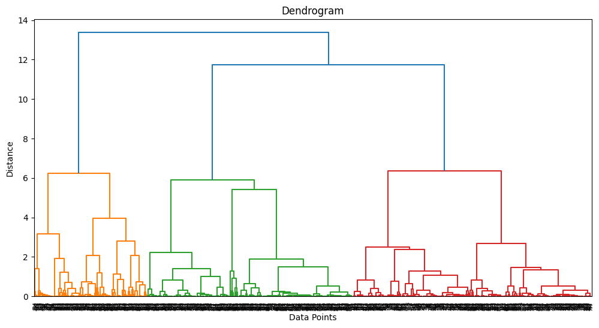

```python
print("Creating dendrogram visualization...")

try:
    # Create figure
    plt.figure(figsize=(12, 6))

    # Generate dendrogram
    dendrogram(linked)

    # Add title and labels
    plt.title("Dendrogram")
    plt.xlabel("Data Points")
    plt.ylabel("Distance")

    # Save image
    plt.savefig("output/dendrogram.png", bbox_inches='tight')

    # Show plot
    plt.show()

except Exception as e:
    print("Error creating dendrogram:", e)
```

```
Dendrogram visualization display...
```

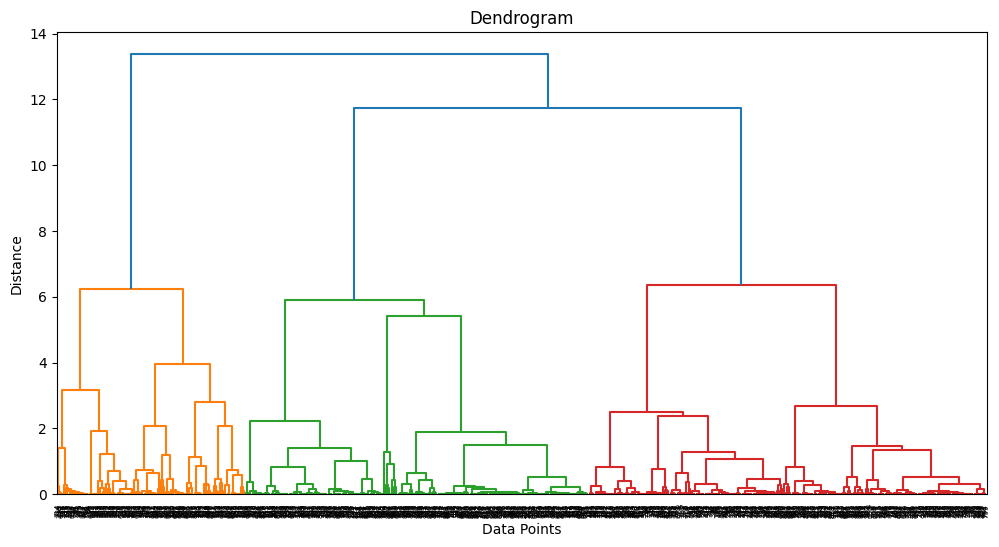

```python
print("Dendrogram visualization display...")

display(Image(filename="output/dendrogram.png"))
```

### PCA Scatter Plot

*Hints:* A PCA scatter plot projects high-dimensional data into 2D using PCA for visualization. Save the image as **pca_scatter_plot.png**. Use **display()** to render the image for html file output. Do not use an html image tag in the markdown, or the image will not print in the html download.

```
Creating scatter plot (PCA Reduced) to visualize clusters in 2D...
```

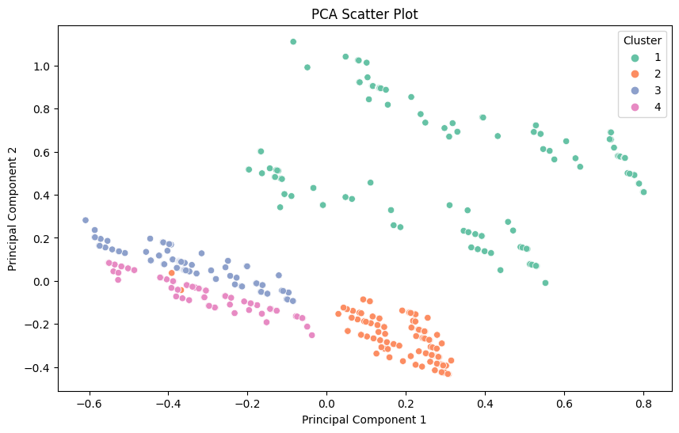

```
Saved successfully to output/pca_scatter_plot.png
```

```python
print("Creating scatter plot (PCA Reduced) to visualize clusters in 2D...")

import os

try:
    # Create output folder if missing
    os.makedirs("output", exist_ok=True)

    # PCA
    pca = PCA(n_components=2)
    pca_result = pca.fit_transform(sample_data)

    # Dataframe
    pca_df = pd.DataFrame(
        pca_result,
        columns=["PCA1", "PCA2"]
    )

    # Cluster labels
    pca_df["Cluster"] = cluster_labels

    # Plot
    plt.figure(figsize=(10,6))

    sns.scatterplot(
        data=pca_df,
        x="PCA1",
        y="PCA2",
        hue="Cluster",
        palette="Set2"
    )

    plt.title("PCA Scatter Plot")
    plt.xlabel("Principal Component 1")
    plt.ylabel("Principal Component 2")

    # Save image
    plt.savefig("output/pca_scatter_plot.png", bbox_inches="tight")

    plt.show()

    print("Saved successfully to output/pca_scatter_plot.png")

except Exception as e:
    print("Error:", e)
```

```
PCA scatter plot visualization display...
```

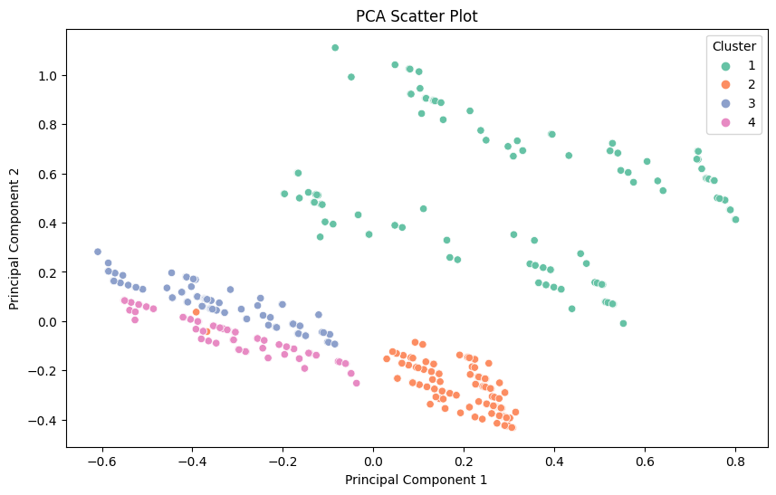

```python
print("PCA scatter plot visualization display...")

display(Image(filename="output/pca_scatter_plot.png"))
```

### Cluster Size Distribution

*Hints:* A cluster size distribution displays the population size of each cluster. Save the image as **cluster_size.png**. Use **display()** to render the image for html file output. Do not use an html image tag in the markdown, or the image will not print in the html download.

```
Creating cluster size distribution chart to analyze cluster sizes...
```

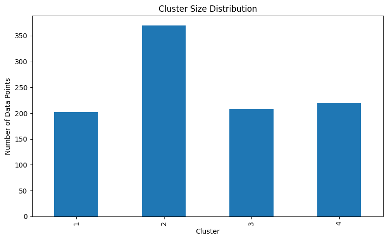

```
Saved successfully to output/cluster_size.png
```

```python
print("Creating cluster size distribution chart to analyze cluster sizes...")

import os

try:
    # Create output folder if it doesn't exist
    os.makedirs("output", exist_ok=True)

    # Count number of items in each cluster
    cluster_counts = pd.Series(cluster_labels).value_counts().sort_index()

    # Plot cluster size distribution
    plt.figure(figsize=(8,5))

    cluster_counts.plot(
        kind='bar'
    )

    plt.title("Cluster Size Distribution")
    plt.xlabel("Cluster")
    plt.ylabel("Number of Data Points")

    plt.tight_layout()

    # Save image
    plt.savefig("output/cluster_size.png", bbox_inches="tight")

    plt.show()

    print("Saved successfully to output/cluster_size.png")

except Exception as e:
    print("Error creating cluster size distribution:", e)
```

```
Cluster size distribution visualization display...
```

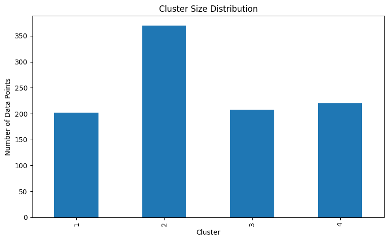

```python
print("Cluster size distribution visualization display...")

display(Image(filename="output/cluster_size.png"))
```

### Feature Importance Heatmap

*Hints:* A feature importance heatmap highlights the average feature values for each cluster. Save the image as **heatmap.png**. Use **display()** to render the image for html file output. Do not use an html image tag in the markdown, or the image will not print in the html download.

```
Creating feature importance heatmap to show mean feature values by cluster...
```

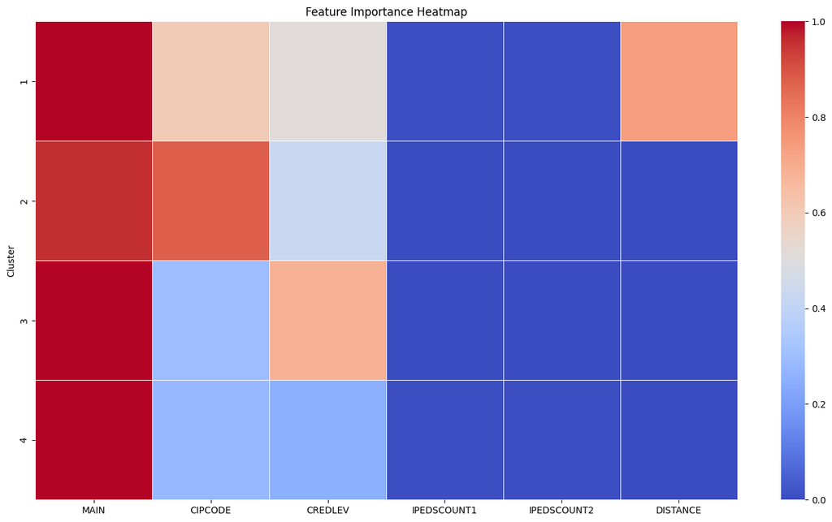

```
Saved successfully to output/heatmap.png
```

```python
print("Creating feature importance heatmap to show mean feature values by cluster...")

import os

try:
    # Create output folder if it doesn't exist
    os.makedirs("output", exist_ok=True)

    # Add cluster labels to the sampled data
    heatmap_df = sample_data.copy()
    heatmap_df["Cluster"] = cluster_labels

    # Calculate average feature values by cluster
    cluster_means = heatmap_df.groupby("Cluster").mean()

    # Create heatmap
    plt.figure(figsize=(14, 8))

    sns.heatmap(
        cluster_means,
        cmap="coolwarm",
        linewidths=0.5
    )

    plt.title("Feature Importance Heatmap")

    plt.tight_layout()

    # Save image
    plt.savefig("output/heatmap.png", bbox_inches="tight")

    plt.show()

    print("Saved successfully to output/heatmap.png")

except Exception as e:
    print("Error creating heatmap:", e)
```

```
Feature importance heatmap visualization display...
```

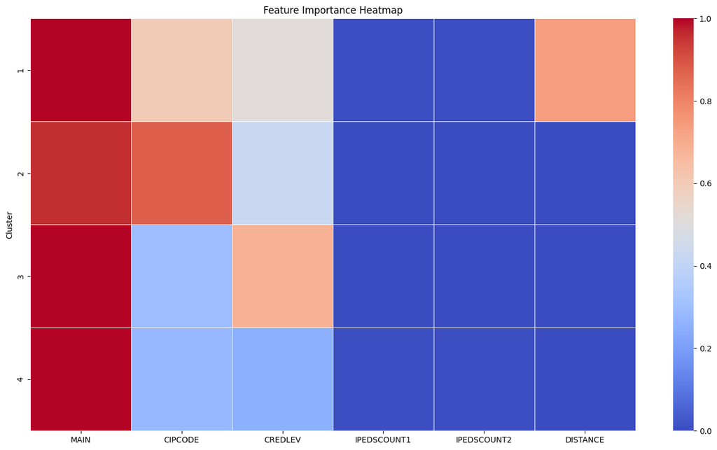

```python
print("Feature importance heatmap visualization display...")

display(Image(filename="output/heatmap.png"))
```

### Trend Chart

*Hints:* A trend chart plots trends in a numeric feature across clusters. Save the image as **trend_chart.png**. Use **display()** to render the image for html file output. Do not use an html image tag in the markdown, or the image will not print in the html download.

```
Creating trend chart to analyze a numeric feature across clusters...
```

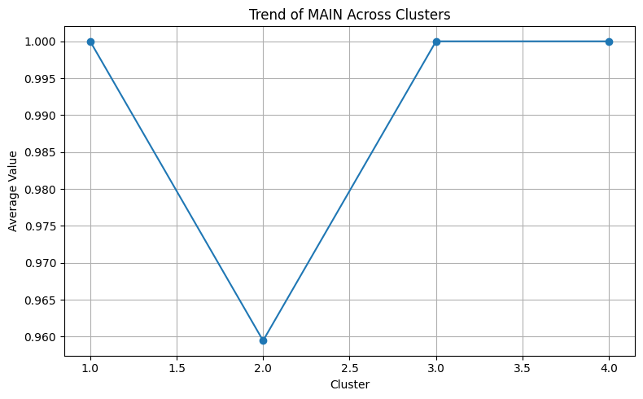

```
Saved successfully to output/trend_chart.png
```

```python
print("Creating trend chart to analyze a numeric feature across clusters...")

import os

try:
    # Create output folder if needed
    os.makedirs("output", exist_ok=True)

    # Add cluster labels
    trend_df = sample_data.copy()
    trend_df["Cluster"] = cluster_labels

    # Select first numeric feature
    feature_name = trend_df.columns[0]

    # Average by cluster
    trend_data = trend_df.groupby("Cluster")[feature_name].mean()

    # Plot line chart
    plt.figure(figsize=(8,5))

    trend_data.plot(
        kind='line',
        marker='o'
    )

    plt.title(f"Trend of {feature_name} Across Clusters")
    plt.xlabel("Cluster")
    plt.ylabel("Average Value")

    plt.grid(True)

    plt.tight_layout()

    # Save image
    plt.savefig("output/trend_chart.png", bbox_inches="tight")

    plt.show()

    print("Saved successfully to output/trend_chart.png")

except Exception as e:
    print("Error creating trend chart:", e)
```

```
Trend chart visualization display...
```

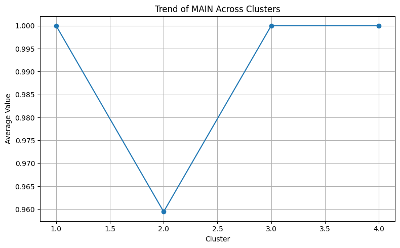

```python
print("Trend chart visualization display...")

display(Image(filename="output/trend_chart.png"))
```

### Scatter Plot

*Hints:* A scatter plot explores the relationship between two features, grouped by clusters. Save the image as **scatter_plot.png**. Use **display()** to render the image for html file output. Do not use an html image tag in the markdown, or the image will not print in the html download.

```
Creating scatter plot of two features grouped by clusters...
```

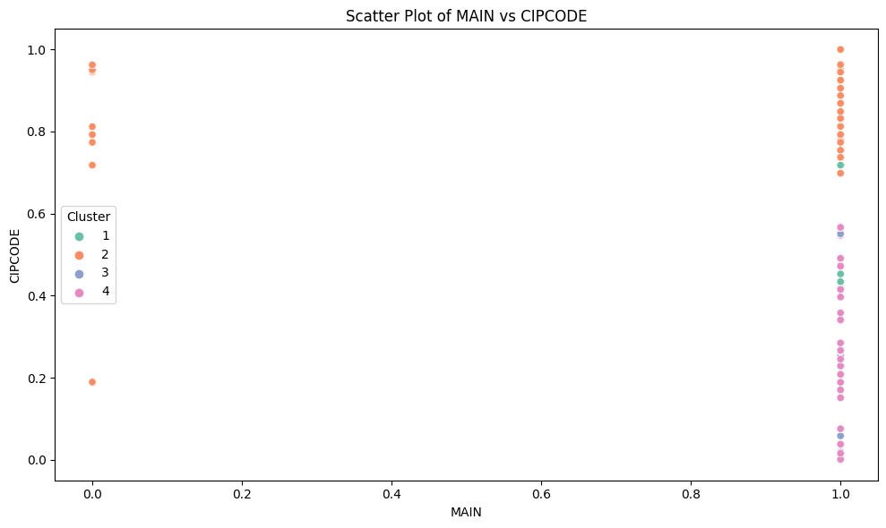

```
Saved successfully to output/scatter_plot.png
```

```python
print("Creating scatter plot of two features grouped by clusters...")

import os

try:
    # Create output folder if missing
    os.makedirs("output", exist_ok=True)

    # Copy sample data
    scatter_df = sample_data.copy()

    # Add cluster labels
    scatter_df["Cluster"] = cluster_labels

    # Choose first two numeric columns
    x_feature = scatter_df.columns[0]
    y_feature = scatter_df.columns[1]

    # Create scatter plot
    plt.figure(figsize=(10,6))

    sns.scatterplot(
        data=scatter_df,
        x=x_feature,
        y=y_feature,
        hue="Cluster",
        palette="Set2"
    )

    plt.title(f"Scatter Plot of {x_feature} vs {y_feature}")
    plt.xlabel(x_feature)
    plt.ylabel(y_feature)

    plt.tight_layout()

    # Save image
    plt.savefig("output/scatter_plot.png", bbox_inches="tight")

    plt.show()

    print("Saved successfully to output/scatter_plot.png")

except Exception as e:
    print("Error creating scatter plot:", e)
```

```
Scatter plot visualization display...
```

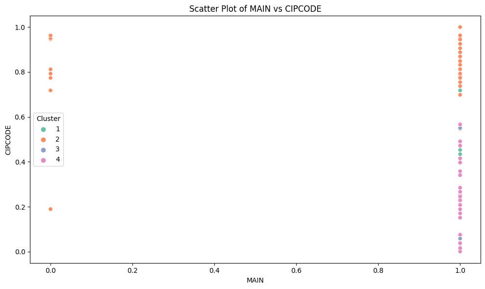

```python
print("Scatter plot visualization display...")

display(Image(filename="output/scatter_plot.png"))
```

## Part 2: Reflection

*This part is to be completed in a word document, using the output above to answer the topics.*

### Identify patterns in the data. Consider the following:

- Are there any clear trends, clusters, or outliers visible in your visualizations?
- Are certain variables showing consistent behavior or relationships?
- Are the patterns similar across different visualization types?

### Draw conclusions from the patterns. Consider the following:

- Are your conclusions clearly based on the patterns you observed?
- Are your findings supported by multiple visuals or data points?

### Explain how the visualizations validate your findings. Consider the following:

- Are specific chart elements (e.g., color, scale, labels) helping to highlight your findings?
- Are the insights you found something you could not easily see without the visuals?

### Write a summary of the visualization choices you made. Include the following:

- An explanation of the types of charts you used
- An explanation of the formatting decisions to support visual clarity